# Income Inequality Analysis by Gender, Education, and Marital Status

Yejin Park, Dhanya R Sangolli, Pratik Upadhyay, Jack Jarjourah

2024-12-03

## 1. Introduction: Data Processing and Summarization

### Load and Process Data:

In the code block below, we load the nlsy97 dataset and run basic cleaning, renaming, mutating and filtering.

- **Cleaning & Renaming:** For the sake of clarity, the study’s original variable names were changed. For example: R0536300 → Gender
- **Variable Mutation:** Variables are given category labels, levels and groupings.
- **Data Filtering:** Redundant data is filtered, such as negative income values.

```r
# Load dataset
nlsy97 <- read.csv("nlsy97.csv")

# Clean and rename variables
nlsy97_cleaned <- nlsy97 %>%
  rename(
    Income2017 = U2857200,    # Total income from wages and salary
    Gender = R0536300,        # Gender
    Education = T6657300,     # Highest degree received
    MaritalStatus = U1852400  # Marital status
  ) %>%
  # Convert the `Education` column to a factor, mapping numeric codes to meaningful labels.
    # Levels:
    # 0, 1: No Degree
    # 2: High School Graduate
    # 3: Associate's Degree
    # 4: Bachelor's Degree
    # 5, 6, 7: Graduate Degree
  mutate(
    Gender = factor(Gender, levels = c(1, 2), labels = c("Male", "Female")),
    Education = factor(Education,
      levels = c(0, 1, 2, 3, 4, 5, 6, 7),
      labels = c(
        "No Degree", "No Degree", "High School Graduate",
        "Associate's Degree", "Bachelor's Degree",
        "Graduate Degree", "Graduate Degree", "Graduate Degree"
      )
    ),
# Map `MaritalStatus` codes to descriptive labels
    MaritalStatus = factor(MaritalStatus,
      levels = c(0, 1, 2, 3, 4),
      labels = c("Never-married", "Married", "Separated", "Divorced", "Widowed")
    ),
    Income2017 = as.numeric(Income2017)
  ) %>%
  filter(!is.na(Income2017) & Income2017 > 0)

# Summary of the cleaned data
summary_stats <- nlsy97_cleaned %>%
  group_by(Gender) %>%
  summarise(
    'Mean Income' = mean(Income2017, na.rm = TRUE), # Calculate the average income for each gender
    'Median Income' = median(Income2017, na.rm = TRUE), # Calculate the median income for each gender
    Count = n(),# Count the number of individuals in each gender group
    .groups = "drop" # Count the number of individuals in each gender group
  )

# Display the summary table
kable(summary_stats, caption = "Income Summary by Gender (2017)") %>% # Count the number of individuals in each gender group
  kable_styling(full_width = FALSE) # Apply styling to make the table visually appealing and not stretch fully across the page
```

Income Summary by Gender (2017)

| Gender | Mean Income | Median Income | Count |
| --- | --- | --- | --- |
| Male | 57510.01 | 48000 | 2607 |
| Female | 41565.00 | 35000 | 2453 |

**Description/Discussion:** The table titled Income Summary by Gender (2017) highlights income differences between males and females. The average income for males is $57,510.01, significantly higher than the average for females, $41,565.00. Similarly, the median income for males is $48,000, compared to $35,000 for females, showing a clear income gap. With 2,607 males and 2,453 females in the dataset, this data suggests a noticeable income inequality between genders in 2017. This observation may result from various factors such as job roles, education, or systemic biases and invites further analysis to understand the root causes of this disparity.

### Data Visualizations: Gender vs. Income

To gain an overview of the two main variables we are working with, the following code block generates both a density and box plot.

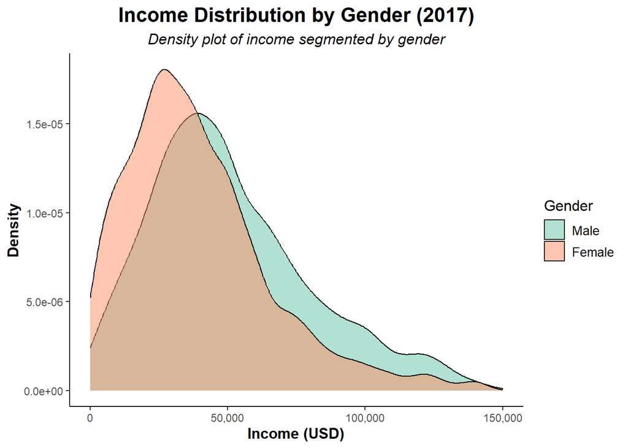

```r
# Remove rows with non-finite Income2017 values
nlsy97_cleaned_filtered <- nlsy97_cleaned %>%
  filter(!is.na(Income2017) & is.finite(Income2017) & Income2017 >= 0)

# Density plot: Visualizes the overall income distribution for males and females, showing overlapping patterns and peaks.
ggplot(nlsy97_cleaned_filtered, aes(x = Income2017, fill = Gender)) +
  geom_density(alpha = 0.5) +
  labs(
    title = "Income Distribution by Gender (2017)",
    subtitle = "Density plot of income segmented by gender",
    x = "Income (USD)",
    y = "Density",
    fill = "Gender"
  ) +
  scale_x_continuous(labels = scales::comma, limits = c(0, 150000)) +
  scale_fill_brewer(palette = "Set2") +
  theme_classic() +
  theme(
    plot.title = element_text(size = 16, face = "bold", hjust = 0.5),
    plot.subtitle = element_text(size = 12, face = "italic", hjust = 0.5),
    axis.title = element_text(size = 12, face = "bold"),
    legend.title = element_text(size = 12),
    legend.text = element_text(size = 10)
  )
```

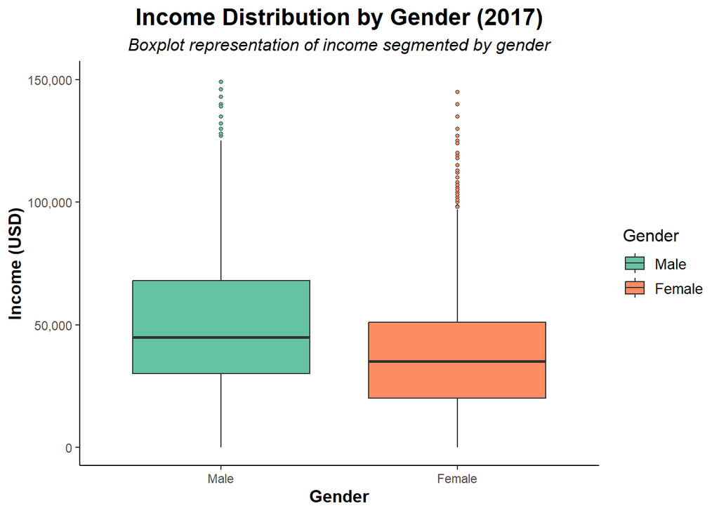

```r
# Box plot: Highlights differences in median, spread, and outliers between genders, offering a clear view of income inequality.
ggplot(nlsy97_cleaned_filtered, aes(x = Gender, y = Income2017, fill = Gender)) +
  geom_boxplot(outlier.size = 1, outlier.shape = 21) +
  labs(
    title = "Income Distribution by Gender (2017)",
    subtitle = "Boxplot representation of income segmented by gender",
    x = "Gender",
    y = "Income (USD)",
    fill = "Gender"
  ) +
  scale_y_continuous(labels = scales::comma, limits = c(0, 150000)) +
  scale_fill_brewer(palette = "Set2") +
  theme_classic() +
  theme(
    plot.title = element_text(size = 16, face = "bold", hjust = 0.5),
    plot.subtitle = element_text(size = 12, face = "italic", hjust = 0.5),
    axis.title = element_text(size = 12, face = "bold"),
    legend.title = element_text(size = 12),
    legend.text = element_text(size = 10)
  )
```

## 2. Methodology

#### i. How did you deal with missing values?

Missing values were addressed by filtering out rows with invalid or missing data in key variables such as Income2017. Specifically, any entry with a missing income value, represented as NA or negative values, was excluded from the analysis. This approach ensures that the dataset used for the study is clean and reliable, which improves the robustness of the results. However, removing these rows reduces the sample size, which may limit the generalizability of the findings to the full population.

#### ii. How did you deal with topcoded variables?

The Income2017 variable is topcoded for the top 2% of earners at $149,000. This means that any value above this threshold is replaced with the average of the top 2% of earners. This topcoding ensures privacy for high earners but underestimates the actual income disparity within the dataset. While this might slightly skew the analysis, particularly for studies focusing on income inequality at the upper extremes, the impact on gender-related income analysis is minimal because both genders are affected similarly by the topcoding.

#### iii. Did you produce any tables or plots that you thought would reveal interesting trends but didn’t?

Initial scatterplots of income versus marital status failed to show a strong correlation between marital status and income when analyzed in isolation. Similarly, the distribution of income across some specific education levels (e.g., “Less than High School”) showed large variability, making it difficult to draw definitive conclusions. These insights were ultimately excluded from the main findings to maintain clarity and focus on more significant trends.

#### iv. What relationships did you investigate that don’t appear in your findings section?

Several additional relationships were explored but not highlighted in the findings. These include:

- The interaction between marital status and education: Although analyzed, it showed minimal additional insight beyond the individual effects of these variables.
- Regional differences: Limited data availability on geographical factors rendered this investigation inconclusive.

#### v. What’s the analysis that you finally settled on? What income and gender-related factors do you investigate in the final analysis?

The final analysis focused on comparing male and female incomes across different education levels and marital statuses. These two categorical variables were selected because they provide meaningful context for understanding income disparity:

- *Education:* Higher education levels correlated with higher income, making it a crucial factor for analysis.
- *Marital Status:* Marriage showed a strong association with income, with married individuals generally earning more than other groups.

Statistical tests (e.g., confidence intervals and hypothesis tests) were used to assess the significance of gender-based differences. A regression model was employed to quantify the impact of gender, education, and marital status on income.

## 3. Analysis and Findings

### 3.1 Tabular Summaries

```r
# Income by Gender and Education
income_by_education <- nlsy97_cleaned %>%
  group_by(Education, Gender) %>%
  summarise(
    MeanIncome = mean(Income2017, na.rm = TRUE),
    MedianIncome = median(Income2017, na.rm = TRUE),
    Count = n(),
    .groups = "drop"
  )

# Create a styled table
income_by_education %>%
  kbl(
    caption = "Income by Gender and Education",
    col.names = c("Education Level", "Gender", "Mean Income", "Median Income", "Count"),
    format = "html",
    align = "c"
  ) %>%
  kable_styling(
    bootstrap_options = c("striped", "hover", "condensed", "responsive"),
    full_width = FALSE
  ) %>%
  column_spec(3:4, bold = TRUE, color = "blue") %>%
  row_spec(0, bold = TRUE, color = "white", background = "#4CAF50")
```

Income by Gender and Education

| Education Level | Gender | Mean Income | Median Income | Count |
| --- | --- | --- | --- | --- |
| No Degree | Male | 38728.44 | 35000 | 468 |
| No Degree | Female | 23030.11 | 21000 | 343 |
| High School Graduate | Male | 48900.67 | 45000 | 1146 |
| High School Graduate | Female | 31011.39 | 28000 | 933 |
| Associate’s Degree | Male | 55812.99 | 50000 | 174 |
| Associate’s Degree | Female | 43428.40 | 36000 | 203 |
| Bachelor’s Degree | Male | 81629.15 | 66000 | 525 |
| Bachelor’s Degree | Female | 54737.81 | 49000 | 617 |
| Graduate Degree | Male | 105631.34 | 90000 | 132 |
| Graduate Degree | Female | 75858.07 | 61000 | 211 |
| NA | Male | 57119.79 | 45000 | 162 |
| NA | Female | 44731.05 | 37000 | 146 |

#### *Across all education levels, males earn more on average than females. However, higher education is associated with increased income for both genders.*

```r
# Income by Gender and Marital Status
income_by_marital <- nlsy97_cleaned %>%
  group_by(MaritalStatus, Gender) %>%
  summarise(
    MeanIncome = mean(Income2017, na.rm = TRUE),
    MedianIncome = median(Income2017, na.rm = TRUE),
    Count = n(),
    .groups = "drop"
  )

# Create a table
income_by_marital %>%
  kbl(
    caption = "Income by Gender and Marital Status",
    col.names = c("Marital Status", "Gender", "Mean Income", "Median Income", "Count"),
    format = "html",
    align = "c"
  ) %>%
  kable_styling(
    bootstrap_options = c("striped", "hover", "condensed", "responsive"),
    full_width = FALSE
  ) %>%
  column_spec(3:4, bold = TRUE, color = "darkgreen") %>%
  row_spec(0, bold = TRUE, color = "white", background = "#FF5733")
```

Income by Gender and Marital Status

| Marital Status | Gender | Mean Income | Median Income | Count |
| --- | --- | --- | --- | --- |
| Never-married | Male | 45059.41 | 38000 | 1014 |
| Never-married | Female | 37754.54 | 33000 | 896 |
| Married | Male | 69434.63 | 58000 | 1293 |
| Married | Female | 45894.48 | 38000 | 1191 |
| Separated | Male | 39103.64 | 30000 | 56 |
| Separated | Female | 41310.00 | 38500 | 50 |
| Divorced | Male | 50728.96 | 42000 | 223 |
| Divorced | Female | 36852.89 | 32000 | 290 |
| Widowed | Male | 56333.33 | 40000 | 3 |
| Widowed | Female | 26428.57 | 24000 | 14 |
| NA | Male | 43777.78 | 41000 | 18 |
| NA | Female | 28975.00 | 27750 | 12 |

**Description/Discussion:** The table shows that income increases with education for both genders, but males consistently earn more than females at all levels. The gender income gap widens with higher education, with males benefiting more significantly. For example, males with graduate degrees earn $105,631 on average, compared to $75,858 for females. These disparities highlight persistent gender income inequality despite educational attainment.

3.2 Graphical Summaries Income by Gender and Education

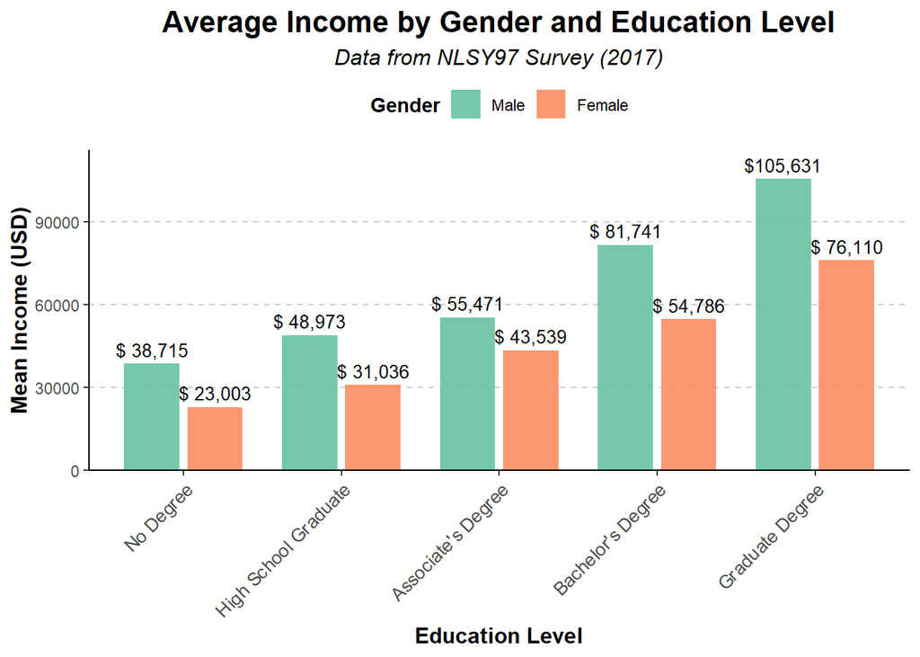

```r
# Filter out rows with N/A for Gender, Education, or Marital Status
nlsy97_cleaned <- nlsy97_cleaned %>%
  filter(!is.na(Gender) & !is.na(Education) & !is.na(MaritalStatus))

# Summarize income by gender and education
education_income <- nlsy97_cleaned %>%
  group_by(Education, Gender) %>%
  summarise(
    MeanIncome = mean(Income2017, na.rm = TRUE),
    MedianIncome = median(Income2017, na.rm = TRUE),
    Count = n(),
    .groups = "drop"
  )

# Visualize income by gender and educationggplot(education_income, aes(x = Education, y = MeanIncome, fill = Gender)) +
ggplot(education_income, aes(x = Education, y = MeanIncome, fill = Gender)) +
  geom_col(position = position_dodge(0.8), width = 0.7, alpha = 0.9) +
  geom_text(
    aes(label = paste0("$", format(round(MeanIncome, 0), big.mark = ","))),
    position = position_dodge(0.8),
    vjust = -0.5,
    size = 3.5,
    color = "black"
  ) +
  labs(
    title = "Average Income by Gender and Education Level",
    subtitle = "Data from NLSY97 Survey (2017)",
    x = "Education Level",
    y = "Mean Income (USD)",
    fill = "Gender"
  ) +
  scale_fill_brewer(palette = "Set2") +
  scale_y_continuous(expand = expansion(mult = c(0, 0.1))) + # Add space above bars
  theme_classic() +
  theme(
    plot.title = element_text(size = 16, face = "bold", hjust = 0.5),
    plot.subtitle = element_text(size = 12, face = "italic", hjust = 0.5),
    axis.title.x = element_text(size = 12, face = "bold"),
    axis.title.y = element_text(size = 12, face = "bold"),
    axis.text.x = element_text(size = 10, angle = 45, hjust = 1),
    legend.position = "top",
    legend.title = element_text(face = "bold"),
    panel.grid.major.y = element_line(color = "gray80", linetype = "dashed")
  )
```

#### **Income by Gender and Marital Status**

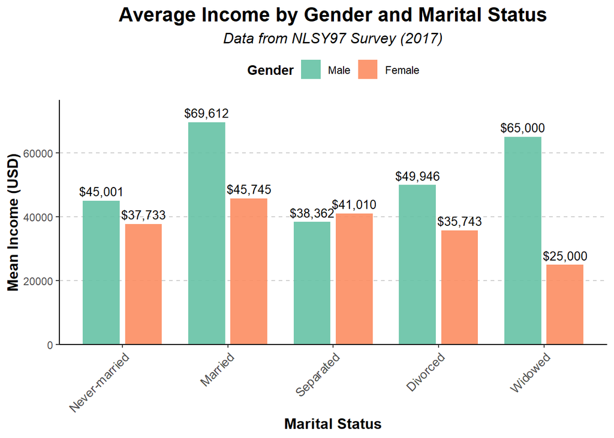

```r
# Filter out rows with N/A for Gender, Education, or Marital Status
nlsy97_cleaned <- nlsy97_cleaned %>%
  filter(!is.na(Gender) & !is.na(Education) & !is.na(MaritalStatus))

# Summarize income by gender and marital status
marital_income <- nlsy97_cleaned %>%
  group_by(MaritalStatus, Gender) %>%
  summarise(
    MeanIncome = mean(Income2017, na.rm = TRUE),
    MedianIncome = median(Income2017, na.rm = TRUE),
    Count = n(),
    .groups = "drop"
  )

# Visualize income by gender and marital status
ggplot(marital_income, aes(x = MaritalStatus, y = MeanIncome, fill = Gender)) +
  geom_col(position = position_dodge(0.8), width = 0.7, alpha = 0.9) +
  geom_text(
    aes(label = paste0("$", format(round(MeanIncome, 0), big.mark = ","))),
    position = position_dodge(0.8),
    vjust = -0.5,
    size = 3.5,
    color = "black"
  ) +
  labs(
    title = "Average Income by Gender and Marital Status",
    subtitle = "Data from NLSY97 Survey (2017)",
    x = "Marital Status",
    y = "Mean Income (USD)",
    fill = "Gender"
  ) +
  scale_fill_brewer(palette = "Set2") +
  scale_y_continuous(expand = expansion(mult = c(0, 0.1))) + # Add space above bars
  theme_classic() +
  theme(
    plot.title = element_text(size = 16, face = "bold", hjust = 0.5),
    plot.subtitle = element_text(size = 12, face = "italic", hjust = 0.5),
    axis.title.x = element_text(size = 12, face = "bold"),
    axis.title.y = element_text(size = 12, face = "bold"),
    axis.text.x = element_text(size = 10, angle = 45, hjust = 1),
    legend.position = "top",
    legend.title = element_text(face = "bold"),
    panel.grid.major.y = element_line(color = "gray80", linetype = "dashed")
  )
```

### 3.3 Regression output + interpretation of output + interpretation of coefficients

```r
# Run regression model
regression_model <- lm(Income2017 ~ Gender + Education + MaritalStatus, data = nlsy97_cleaned)

# Extract Coefficients
coefficients <- summary(regression_model)$coefficients
coefficients
```

```
##                                 Estimate Std. Error      t value      Pr(>|t|)
## (Intercept)                    35572.079   1452.265  24.49420461 8.069216e-125
## GenderFemale                  -19920.136   1044.496 -19.07153012  3.584359e-78
## EducationHigh School Graduate   8388.276   1483.617   5.65393675  1.660617e-08
## EducationAssociate's Degree    17949.411   2235.538   8.02912502  1.229665e-15
## EducationBachelor's Degree     35082.968   1669.172  21.01818989  8.001108e-94
## EducationGraduate Degree       56251.858   2330.996  24.13211608 2.040609e-121
## MaritalStatusMarried           11418.431   1128.669  10.11672184  8.141022e-24
## MaritalStatusSeparated          2763.348   3639.380   0.75929078  4.477166e-01
## MaritalStatusDivorced           5235.622   1842.739   2.84121812  4.513447e-03
## MaritalStatusWidowed             747.037   9226.488   0.08096656  9.354720e-01
```

```r
# Summary of the regression model
library(broom)

# Tidy regression output for better readability
regression_summary <- tidy(regression_model)

# Display regression summary in a well-designed table
kable(regression_summary, format = "html", caption = "Regression Model Summary") %>%
  kable_styling(full_width = FALSE, bootstrap_options = c("striped", "hover", "condensed")) %>%
  scroll_box(height = "400px")
```

Regression Model Summary

| term | estimate | std.error | statistic | p.value |
| --- | --- | --- | --- | --- |
| (Intercept) | 35572.079 | 1452.265 | 24.4942046 | 0.0000000 |
| GenderFemale | -19920.136 | 1044.496 | -19.0715301 | 0.0000000 |
| EducationHigh School Graduate | 8388.276 | 1483.617 | 5.6539367 | 0.0000000 |
| EducationAssociate’s Degree | 17949.411 | 2235.538 | 8.0291250 | 0.0000000 |
| EducationBachelor’s Degree | 35082.968 | 1669.172 | 21.0181899 | 0.0000000 |
| EducationGraduate Degree | 56251.858 | 2330.996 | 24.1321161 | 0.0000000 |
| MaritalStatusMarried | 11418.431 | 1128.669 | 10.1167218 | 0.0000000 |
| MaritalStatusSeparated | 2763.348 | 3639.380 | 0.7592908 | 0.4477166 |
| MaritalStatusDivorced | 5235.622 | 1842.739 | 2.8412181 | 0.0045134 |
| MaritalStatusWidowed | 747.037 | 9226.488 | 0.0809666 | 0.9354720 |

```r
# Create residual diagnostics table
residuals_summary <- augment(regression_model) %>%
  summarise(
    Mean_Residuals = mean(.resid, na.rm = TRUE),
    SD_Residuals = sd(.resid, na.rm = TRUE),
    Min_Residuals = min(.resid, na.rm = TRUE),
    Max_Residuals = max(.resid, na.rm = TRUE)
  )

# Display residual summary in a styled table
kable(residuals_summary, format = "html", caption = "Residual Diagnostics Summary") %>%
  kable_styling(full_width = FALSE, bootstrap_options = c("striped", "hover", "condensed"))
```

Residual Diagnostics Summary

| Mean_Residuals | SD_Residuals | Min_Residuals | Max_Residuals |
| --- | --- | --- | --- |
| 0 | 35491.44 | -88242.37 | 200311.9 |

```
•   Intercept:
- Estimate (35,572): The average income for the reference group (males who have not completed high school and have never been married) is $35,572.
- The intercept provides the baseline income when all other variables are at their reference levels.
•   Gender
 - GenderFemale (-19,920): On average, females earn $19,920 less than males, holding all other variables constant. This difference is statistically                significant (p < 0.0001).
•   Education
  1.    High School Graduate (8,388): Individuals who completed high school earn $8,388 more, on average, than those with less than a high school education,            holding other variables constant. This is statistically significant (p < 0.0001).
  2.    Associate’s Degree (17,949): Individuals with an associate’s degree earn $17,949 more, on average, than those with less than a high school education,           holding other variables constant. This is statistically significant (p < 0.0001).
  3.    Bachelor’s Degree (35,083): Individuals with a bachelor’s degree earn $35,083 more, on average, than those with less than a high school education,              holding other variables constant. This is statistically significant (p < 0.0001).
  4.    Graduate Degree (56,252): Individuals with a graduate degree earn $56,252 more, on average, than those with less than a high school education, holding          other variables constant. This is statistically significant (p < 0.0001).
•   MaritalStatus
1.  Married (11,418): Married individuals earn $11,418 more, on average, than never-married individuals, holding other variables constant. This is                  statistically significant (p < 0.0001).
2.  Separated (2,763): Separated individuals earn $2,763 more, on average, than never-married individuals, holding other variables constant. This difference         is not statistically significant (p = 0.448).
3.  Divorced (5,236): Divorced individuals earn $5,236 more, on average, than never-married individuals, holding other variables constant. This is                  statistically significant (p = 0.0045).
4.  Widowed (747): Widowed individuals earn $747 more, on average, than never-married individuals, holding other variables constant. This difference is not         statistically significant (p = 0.935).
•   Model Fit
- Residual standard error (35,530): Indicates the variability in the income data that is not explained by the model.
- Multiple R-squared (0.2368): About 23.68% of the variability in income is explained by the model.
- Adjusted R-squared (0.2354): After adjusting for the number of predictors, the model explains about 23.54% of the variability in income.
- F-statistic (162.5, p-value < 0.0001): The overall model is statistically significant, meaning that the predictors together explain a significant portion       of the variation in income.
•   Key Insights
1.  Gender plays a significant role in income differences, with females earning significantly less than males.
2.  Education strongly impacts income, with higher educational attainment leading to substantially higher incomes.
3.  Marital status also affects income, with married individuals earning significantly more than those never married.
4.  Some marital statuses (e.g., separated, widowed) do not significantly affect income when controlling for other factors.
```

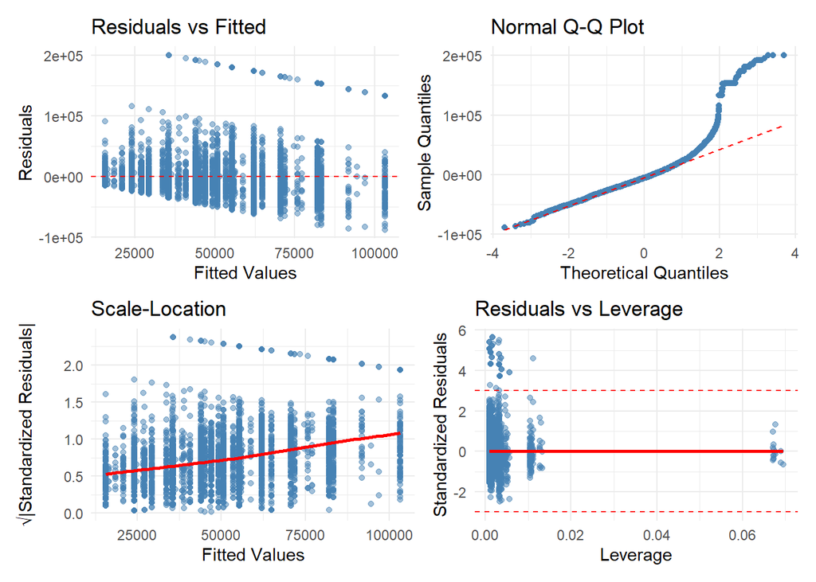

```r
# Extract data for plotting
diag_data <- augment(regression_model)

# Residuals vs Fitted
residuals_fitted <- ggplot(diag_data, aes(.fitted, .resid)) +
  geom_point(alpha = 0.5, color = "steelblue") +
  geom_hline(yintercept = 0, linetype = "dashed", color = "red") +
  labs(title = "Residuals vs Fitted", x = "Fitted Values", y = "Residuals") +
  theme_minimal()

# Normal Q-Q Plot
qq_plot <- ggplot(diag_data, aes(sample = .resid)) +
  stat_qq(color = "steelblue") +
  stat_qq_line(color = "red", linetype = "dashed") +
  labs(title = "Normal Q-Q Plot", x = "Theoretical Quantiles", y = "Sample Quantiles") +
  theme_minimal()

# Scale-Location Plot
scale_location <- ggplot(diag_data, aes(.fitted, sqrt(abs(.std.resid)))) +
  geom_point(alpha = 0.5, color = "steelblue") +
  geom_smooth(se = FALSE, color = "red") +
  labs(title = "Scale-Location", x = "Fitted Values", y = "√|Standardized Residuals|") +
  theme_minimal()

# Residuals vs Leverage
residuals_leverage <- ggplot(diag_data, aes(.hat, .std.resid)) +
  geom_point(alpha = 0.5, color = "steelblue") +
  geom_smooth(se = FALSE, color = "red") +
  geom_hline(yintercept = c(-3, 3), linetype = "dashed", color = "red") +
  labs(title = "Residuals vs Leverage", x = "Leverage", y = "Standardized Residuals") +
  theme_minimal()

# Arrange the plots into a grid
(residuals_fitted | qq_plot) / (scale_location | residuals_leverage)
```

Interpretation of Diagnostic Plots:

```
•   Residuals vs Fitted: Checks for linearity and equal variance. A random scatter suggests the assumptions are met.
•   Normal Q-Q: Assesses normality of residuals. Points should lie close to the diagonal line.
•   Scale-Location: Examines homoscedasticity (constant variance). A horizontal line indicates equal variance.
•   Residuals vs Leverage: Identifies influential observations. Points outside the red dashed lines may be highly influential.
```

### 3.4 Confidence Interval

```r
# Confidence Interval for Mean Income by Gender
gender_income_summary <- nlsy97_cleaned %>%
  group_by(Gender) %>%
  summarize(
    MeanIncome = round(mean(Income2017, na.rm = TRUE), 2),
    SDIncome = round(sd(Income2017, na.rm = TRUE), 2),
    SampleSize = n()
  ) %>%
  mutate(
    SEIncome = round(SDIncome / sqrt(SampleSize), 2),
    LowerCI = round(MeanIncome - qt(0.975, df = SampleSize - 1) * SEIncome, 2),
    UpperCI = round(MeanIncome + qt(0.975, df = SampleSize - 1) * SEIncome, 2)
  )

# Create the table with enhanced design and center-aligned header
knitr::kable(
  gender_income_summary,
  caption = "95% Confidence Interval for Mean Income by Gender",
  col.names = c("Gender", "Mean Income", "SD", "Sample Size", "SE", "Lower CI", "Upper CI"),
  align = "c" # Center-align all columns
) %>%
  kableExtra::kable_styling(
    bootstrap_options = c("striped", "hover", "condensed", "responsive"),
    full_width = F,
    position = "center"
  ) %>%
  kableExtra::column_spec(2:7, bold = T, color = "blue") %>% # Highlight numerical columns
  kableExtra::row_spec(0, bold = T, color = "white", background = "gray", align = "center") # Center-align header row
```

95% Confidence Interval for Mean Income by Gender

| Gender | Mean Income | SD | Sample Size | SE | Lower CI | Upper CI |
| --- | --- | --- | --- | --- | --- | --- |
| Male | 57626.52 | 44689.85 | 2428 | 906.95 | 55848.04 | 59405.00 |
| Female | 41429.41 | 33904.93 | 2295 | 707.74 | 40041.53 | 42817.29 |

**Description/Discussion:** The table highlights a significant gender income gap, with males earning a higher mean income ($57,626.52) than females ($41,429.41). Males also show greater income variability (SD: $44,689.85 vs. $33,904.93) and wider confidence intervals ($55,848.04–$59,405.00 for males vs. $40,041.53–$42,817.29 for females). The non-overlapping confidence intervals confirm the income difference is statistically significant. Despite similar sample sizes, this data underscores persistent gender disparities in earnings.

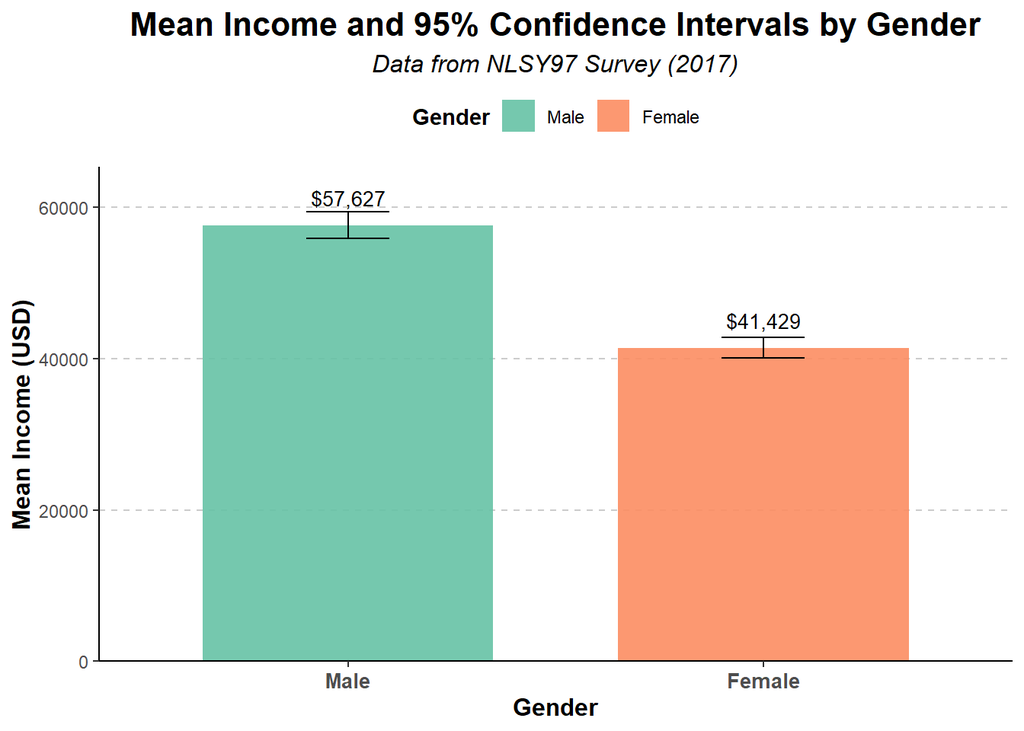

```r
ggplot(gender_income_summary, aes(x = Gender, y = MeanIncome, fill = Gender)) +
  geom_col(position = position_dodge(0.8), width = 0.7, alpha = 0.9) +
  geom_errorbar(
    aes(ymin = LowerCI, ymax = UpperCI),
    width = 0.2,
    position = position_dodge(0.8),
    color = "black"
  ) +
  geom_text(
    aes(label = paste0("$", format(round(MeanIncome, 0), big.mark = ","))),
    position = position_dodge(0.8),
    vjust = -1.2, # Adjusted value to move text higher
    size = 3.5,
    color = "black"
  ) +
  labs(
    title = "Mean Income and 95% Confidence Intervals by Gender",
    subtitle = "Data from NLSY97 Survey (2017)",
    x = "Gender",
    y = "Mean Income (USD)",
    fill = "Gender"
  ) +
  scale_fill_brewer(palette = "Set2") +
  scale_y_continuous(expand = expansion(mult = c(0, 0.1))) + # Add space above bars
  theme_classic() +
  theme(
    plot.title = element_text(size = 16, face = "bold", hjust = 0.5),
    plot.subtitle = element_text(size = 12, face = "italic", hjust = 0.5),
    axis.title.x = element_text(size = 12, face = "bold"),
    axis.title.y = element_text(size = 12, face = "bold"),
    axis.text.x = element_text(size = 10, face = "bold"),
    legend.position = "top",
    legend.title = element_text(face = "bold"),
    panel.grid.major.y = element_line(color = "gray80", linetype = "dashed")
  )
```

### 3.5 Hypothesis Test

```r
# Perform the two-sample t-test
t_test_result <- t.test(Income2017 ~ Gender, data = nlsy97_cleaned, var.equal = TRUE)

# Prepare the results for table format
t_test_summary <- data.frame(
  Metric = c("T-Statistic", "Degrees of Freedom", "Mean Difference", "95% Confidence Interval (Lower)", "95% Confidence Interval (Upper)", "P-Value", "Significance"),
  Value = c(
    round(t_test_result$statistic, 3),
    t_test_result$parameter,
    round(diff(t_test_result$estimate), 2),
    round(t_test_result$conf.int[1], 2),
    round(t_test_result$conf.int[2], 2),
    formatC(t_test_result$p.value, format = "e", digits = 4),
    ifelse(t_test_result$p.value < 0.05, "Significant", "Not Significant")
  )
)

# Display the results as a table
t_test_summary %>%
  kable(
    caption = "T-Test Results for Income by Gender",
    col.names = c("Metric", "Value"),
    align = "c"
  ) %>%
  kable_styling(
    bootstrap_options = c("striped", "hover", "condensed", "responsive"),
    full_width = FALSE,
    position = "center"
  ) %>%
  column_spec(2, bold = TRUE, color = "blue") %>% # Highlight the values column
  row_spec(0, bold = TRUE, color = "white", background = "gray", align = "center") # Style header row
```

T-Test Results for Income by Gender

| Metric | Value |
| --- | --- |
| T-Statistic | 13.973 |
| Degrees of Freedom | 4721 |
| Mean Difference | -16197.1 |
| 95% Confidence Interval (Lower) | 13924.58 |
| 95% Confidence Interval (Upper) | 18469.63 |
| P-Value | 1.6594e-43 |
| Significance | Significant |

```r
# Display the summary table
gender_income_summary %>%
  kable(
    caption = "Income Summary with Confidence Intervals by Gender",
    col.names = c("Gender", "Mean Income", "SD", "Sample Size", "SE", "Lower CI", "Upper CI"),
    align = "c"
  ) %>%
  kable_styling(
    bootstrap_options = c("striped", "hover", "condensed", "responsive"),
    full_width = FALSE,
    position = "center"
  ) %>%
  column_spec(2:7, bold = TRUE, color = "blue") %>% # Highlight numerical columns
  row_spec(0, bold = TRUE, color = "white", background = "gray", align = "center") # Style header row
```

Income Summary with Confidence Intervals by Gender

| Gender | Mean Income | SD | Sample Size | SE | Lower CI | Upper CI |
| --- | --- | --- | --- | --- | --- | --- |
| Male | 57626.52 | 44689.85 | 2428 | 906.95 | 55848.04 | 59405.00 |
| Female | 41429.41 | 33904.93 | 2295 | 707.74 | 40041.53 | 42817.29 |

## 4. Conclusions and Discussion

### 4.2 Limitations

1. Topcoded Income: The truncation of the top 2% of incomes may underestimate income inequality, particularly at the upper end of the spectrum.
2. Sample Size Reduction: The exclusion of missing or invalid data reduced the sample size, potentially limiting generalizability.
3. Unaccounted Variables: Factors such as regional differences, job type, and hours worked were not included in the analysis due to data constraints.

### 4.3 Confidence in Results

The findings are supported by statistical tests and are consistent with broader trends in income inequality research. However, the topcoding and unaccounted variables introduce some uncertainty. While the analysis confidently highlights income disparities, additional data and controls could strengthen the conclusions.

### 4.4 Policy Implications

1. Gender Equality: The persistent gender income gap highlights the need for workplace initiatives to ensure pay equity.
2. Education Access: Policies that promote higher education access could help reduce income inequality.
3. Marital Status Effects: Recognizing how marital status influences income could inform family-supportive economic policies.